# Exploring the P/NBD Model on the Synthetic Dataset

# 1 Fit Synthetic Data Model

We take our transaction data and transform the data into a format amenable for the BTYD models.

We first ensure that all transactions on the same day or combined into a single transaction, and then convert this data into the $(x, t_x, T)$ triplet-format.

To mimic the training / test split to help validate real-world models, we do the same thing here.

```r
synth_training_date <- as.Date("2016-12-31")
```

We also wish to load the generated data.

```r
customer_synth_cohort_tbl <- read_rds("data/customer_synth_050000_cohort_tbl.rds")
customer_synth_cohort_tbl %>% glimpse()
```

```
## Rows: 50,000
## Columns: 4
## $ customer_id    <chr> "CUST201101-0001", "CUST201101-0002", "CUST201101-0003"…
## $ cohort_qtr     <chr> "2011 Q1", "2011 Q1", "2011 Q1", "2011 Q1", "2011 Q1", …
## $ cohort_ym      <chr> "2011 01", "2011 01", "2011 01", "2011 01", "2011 01", …
## $ first_tnx_date <date> 2011-01-01, 2011-01-01, 2011-01-01, 2011-01-01, 2011-0…
```

```r
customer_synth_simparams_tbl <- read_rds("data/customer_synth_050000_simparams_tbl.rds")
customer_synth_simparams_tbl %>% glimpse()
```

```
## Rows: 50,000
## Columns: 9
## $ customer_id     <chr> "CUST201101-0001", "CUST201101-0002", "CUST201101-0003…
## $ cohort_qtr      <chr> "2011 Q1", "2011 Q1", "2011 Q1", "2011 Q1", "2011 Q1",…
## $ cohort_ym       <chr> "2011 01", "2011 01", "2011 01", "2011 01", "2011 01",…
## $ first_tnx_date  <date> 2011-01-01, 2011-01-01, 2011-01-01, 2011-01-01, 2011-…
## $ customer_mu     <dbl> 0.071748780, 0.248420319, 0.006058368, 0.051384521, 0.…
## $ customer_tau    <dbl> 3.4743693, 1.3558206, 549.0133792, 52.9733824, 7.70020…
## $ customer_lambda <dbl> 0.07278501, 0.26897420, 0.27091942, 0.19002697, 0.2265…
## $ customer_nu     <dbl> 0.40085736, 0.04897407, 0.83194416, 0.42815577, 0.6042…
## $ customer_p      <dbl> 100, 100, 100, 100, 100, 100, 100, 100, 100, 100, 100,…
```

```r
customer_synth_transactions_tbl <- read_rds("data/customer_synth_050000_transactions_tbl.rds")
customer_synth_transactions_tbl %>% glimpse()
```

```
## Rows: 522,676
## Columns: 4
## $ customer_id   <chr> "CUST201101-0001", "CUST201101-0013", "CUST201101-0010",…
## $ tnx_timestamp <dttm> 2011-01-01 01:25:41, 2011-01-01 03:26:10, 2011-01-01 03…
## $ invoice_id    <chr> "20110101_0001", "20110101_0002", "20110101_0003", "2011…
## $ tnx_amount    <dbl> 265.09, 48.44, 249.04, 308.81, 61.88, 307.67, 875.11, 15…
```

We now convert the transaction data into the CBS format as an input the BTYD models, aggregating the CBS data to construct our CLV input data.

```r
customer_synth_cbs_tbl <- customer_synth_transactions_tbl %>%
  calculate_transaction_cbs_data(
    last_date = synth_training_date
    ) %>%
  filter(
    first_tnx_date <= synth_training_date,
    x > 0
    )

customer_synth_cbs_tbl %>% glimpse()
```

```
## Rows: 25,642
## Columns: 6
## $ customer_id    <chr> "CUST201101-0002", "CUST201101-0003", "CUST201101-0004"…
## $ first_tnx_date <dttm> 2011-01-01 10:46:50, 2011-01-01 15:18:08, 2011-01-01 2…
## $ last_tnx_date  <dttm> 2011-01-10 14:53:19, 2016-12-16 09:00:54, 2012-01-04 1…
## $ x              <dbl> 1, 75, 15, 1, 67, 5, 7, 9, 5, 1, 4, 11, 4, 1, 4, 18, 4,…
## $ t_x            <dbl> 1.31016705, 310.81971951, 52.50036484, 0.07719749, 230.…
## $ T_cal          <dbl> 312.9358, 312.9089, 312.8644, 312.9394, 312.9030, 312.8…
```

We now write that CBS data to disk for later use.

```r
customer_synth_cbs_tbl %>% write_rds("data/customer_synth_cbs_tbl.rds")
```

We may want to fit our models on reduced datasets, so we construct a sample of 5,000 customers to use for our model, and save those `customer_id` to ensure we use the same reduced dataset each time we fit our models.

```r
reduced_ids <- customer_synth_cbs_tbl %>%
  slice_sample(n = 5000) %>%
  arrange(first_tnx_date) %>%
  pull(customer_id)

reduced_ids %>% glimpse()
```

```
##  chr [1:5000] "CUST201101-0012" "CUST201101-0003" "CUST201101-0019" ...
```

## 1.1 Construct Fixed Hyper-parameter Model

```r
pnbd_synth_fixed_stanmodel <- cmdstan_model(
  "stan_code/clv_pnbd_fixed.stan",
  include_paths = "stan_code/",
  pedantic      =  TRUE,
  dir           = "stan_models/"
  )
```

```r
stan_data_lst <- customer_synth_cbs_tbl %>%
  filter(customer_id %in% reduced_ids) %>%
  select(-first_tnx_date, -last_tnx_date) %>%
  compose_data(
    r     =  1,
    alpha =  3,

    s     =  1,
    beta  = 10,
    )

pnbd_synth_fixed_stanfit <- pnbd_synth_fixed_stanmodel$sample(
  data            =                stan_data_lst,
  chains          =                            4,
  iter_warmup     =                         1000,
  iter_sampling   =                         1000,
  seed            =                          421,
  output_dir      =                "stan_models",
  output_basename =           "pnbd_synth_fixed"
  )
```

[output not shown]

[output cut: 43 more lines]

```
## Chain 1 Iteration: 1900 / 2000 [ 95%]  (Sampling)
## Chain 3 Iteration: 1900 / 2000 [ 95%]  (Sampling)
## Chain 2 Iteration: 1900 / 2000 [ 95%]  (Sampling)
## Chain 4 Iteration: 2000 / 2000 [100%]  (Sampling)
## Chain 4 finished in 261.2 seconds.
## Chain 1 Iteration: 2000 / 2000 [100%]  (Sampling)
## Chain 1 finished in 262.1 seconds.
## Chain 3 Iteration: 2000 / 2000 [100%]  (Sampling)
## Chain 3 finished in 262.9 seconds.
## Chain 2 Iteration: 2000 / 2000 [100%]  (Sampling)
## Chain 2 finished in 265.7 seconds.
##
## All 4 chains finished successfully.
## Mean chain execution time: 263.0 seconds.
## Total execution time: 266.1 seconds.
```

We first want to check the HMC diagnostics.

```r
pnbd_synth_fixed_stanfit$cmdstan_diagnose()
```

```
## Processing csv files: /home/rstudio/workshop/stan_models/pnbd_synth_fixed-1.csv, /home/rstudio/workshop/stan_models/pnbd_synth_fixed-2.csv, /home/rstudio/workshop/stan_models/pnbd_synth_fixed-3.csv, /home/rstudio/workshop/stan_models/pnbd_synth_fixed-4.csv
##
## Checking sampler transitions treedepth.
## Treedepth satisfactory for all transitions.
##
## Checking sampler transitions for divergences.
## No divergent transitions found.
##
## Checking E-BFMI - sampler transitions HMC potential energy.
## E-BFMI satisfactory.
##
## Effective sample size satisfactory.
##
## Split R-hat values satisfactory all parameters.
##
## Processing complete, no problems detected.
```

We use the functionality given by `tidybayes` to extract the posterior distribution of the parameters.

```r
customer_synth_pnbd_fixed_draws <- pnbd_synth_fixed_stanfit$draws()

customer_synth_pnbd_fixed_posterior_tbl <- customer_synth_pnbd_fixed_draws %>%
  recover_types(customer_synth_cbs_tbl) %>%
  spread_draws(mu[customer_id], lambda[customer_id]) %>%
  ungroup()

customer_synth_pnbd_fixed_posterior_tbl %>% glimpse()
```

```
## Rows: 20,000,000
## Columns: 6
## $ customer_id <chr> "CUST201101-0002", "CUST201101-0002", "CUST201101-0002", "…
## $ mu          <dbl> 0.003259360, 0.003269460, 0.000255800, 0.000250664, 0.0003…
## $ .chain      <int> 1, 1, 1, 1, 1, 1, 1, 1, 1, 1, 1, 1, 1, 1, 1, 1, 1, 1, 1, 1…
## $ .iteration  <int> 1, 2, 3, 4, 5, 6, 7, 8, 9, 10, 11, 12, 13, 14, 15, 16, 17,…
## $ .draw       <int> 1, 2, 3, 4, 5, 6, 7, 8, 9, 10, 11, 12, 13, 14, 15, 16, 17,…
## $ lambda      <dbl> 0.229349, 0.254540, 0.244310, 0.249151, 0.271328, 0.212203…
```

```r
customer_posterior_tbl <- customer_synth_pnbd_fixed_posterior_tbl %>%
  group_by(customer_id) %>%
  summarise(
    posterior_mu     = list(mu),
    posterior_lambda = list(lambda)
    )

customer_postcheck_tbl <- customer_synth_simparams_tbl %>%
  select(customer_id, customer_mu, customer_lambda, customer_tau) %>%
  inner_join(customer_posterior_tbl, by = "customer_id") %>%
  mutate(
    post_mu_qval     = map2_dbl(customer_mu,     posterior_mu,     ~ ecdf(.y)(.x)),
    post_lambda_qval = map2_dbl(customer_lambda, posterior_lambda, ~ ecdf(.y)(.x))
    )

customer_postcheck_tbl %>% glimpse()
```

```
## Rows: 5,000
## Columns: 8
## $ customer_id      <chr> "CUST201101-0002", "CUST201101-0003", "CUST201101-000…
## $ customer_mu      <dbl> 0.2484203186, 0.0060583680, 0.0513845210, 0.082395792…
## $ customer_lambda  <dbl> 0.26897420, 0.27091942, 0.19002697, 0.22658111, 0.257…
## $ customer_tau     <dbl> 1.355821, 549.013379, 52.973382, 7.700204, 239.051521…
## $ posterior_mu     <list> <3.25936e-03, 3.26946e-03, 2.55800e-04, 2.50664e-04,…
## $ posterior_lambda <list> <0.229349, 0.254540, 0.244310, 0.249151, 0.271328, 0…
## $ post_mu_qval     <dbl> 1.00000, 0.00925, 0.40800, 1.00000, 0.00200, 0.12225,…
## $ post_lambda_qval <dbl> 0.84900, 0.18250, 0.00000, 1.00000, 0.15075, 0.69175,…
```

We now plot the uniformity of the data.

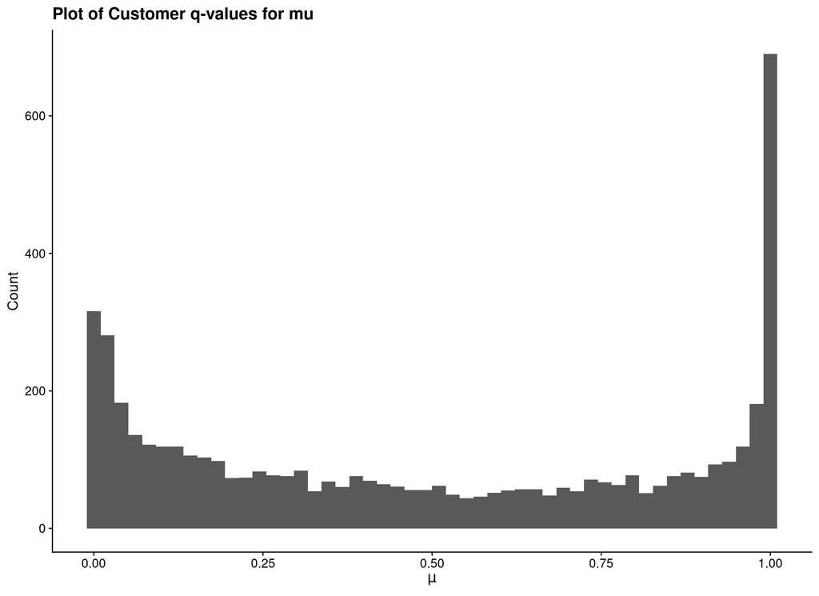

```r
ggplot(customer_postcheck_tbl) +
  geom_histogram(aes(x = post_mu_qval), bins = 50) +
  labs(
    x = expression(mu),
    y = "Count",
    title = "Plot of Customer q-values for mu"
    )
```

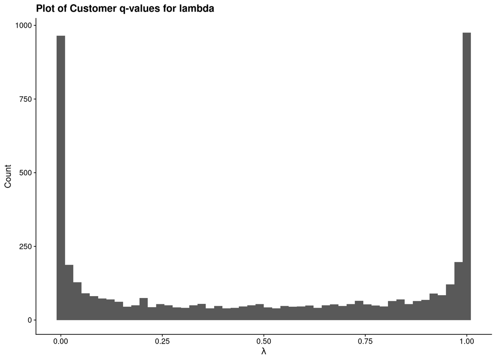

```r
ggplot(customer_postcheck_tbl) +
  geom_histogram(aes(x = post_lambda_qval), bins = 50) +
  labs(
    x = expression(lambda),
    y = "Count",
    title = "Plot of Customer q-values for lambda"
    )
```

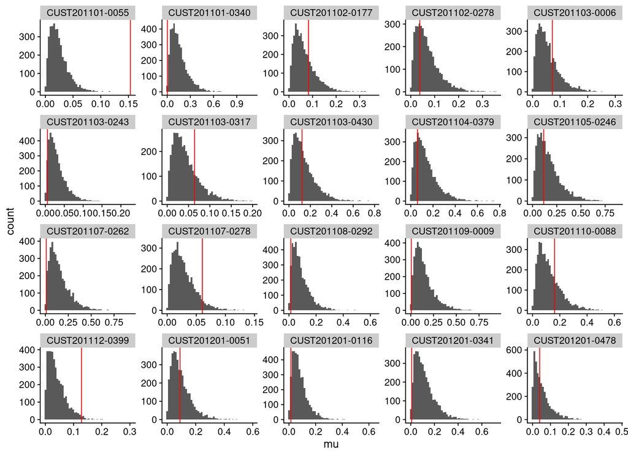

```r
postcheck_facet_plotdata_tbl <- customer_synth_pnbd_fixed_posterior_tbl %>%
  ungroup() %>%
  group_nest(customer_id) %>%
  slice_sample(n = 20) %>%
  unnest(data) %>%
  inner_join(customer_synth_simparams_tbl, by = "customer_id")

ggplot(postcheck_facet_plotdata_tbl) +
  geom_histogram(aes(x = mu), bins = 50) +
  geom_vline(aes(xintercept = customer_mu), colour = "red") +
  facet_wrap(facets = "customer_id", scales = "free")
```

### 1.1.1 Write Model to Disk

```r
pnbd_synth_fixed_stanmodel %>% write_rds("data/pnbd_synth_fixed_stanmodel.rds")
pnbd_synth_fixed_stanfit   %>% write_rds("data/pnbd_synth_fixed_stanfit.rds")
```